Team : We Showed Up Team Members : - Nitya Patel (202051129) - Prathak Garg (202051144) - Pratyush Agrawal(202051145) - Prince Rakoliya (202051147)

```r
library(bnlearn)
library(bnclassify)
library(dplyr)
library(ggplot2)
library(graph)
```

## Problem 1

Consider grades earned in each of the courses as random variables and learn the dependencies between courses.

First we read the data into R.

```r
course.grades<-read.table("2020_bn_nb_data.txt",head=TRUE)
head(course.grades)
```

```
##   EC100 EC160 IT101 IT161 MA101 PH100 PH160 HS101 QP
## 1    BC    CC    BB    BC    CC    BC    AA    BB  y
## 2    CC    BC    BB    BB    CC    BC    AB    BB  y
## 3    AB    BB    AB    AB    BB    CC    BC    AB  y
## 4    BC    CC    BB    BB    BB    BB    BC    BB  y
## 5    BC    AB    CD    BC    BC    BC    BC    CD  y
## 6    DD    CC    DD    CD    CD    CC    BC    BC  n
```

We now get dependencies between the courses.

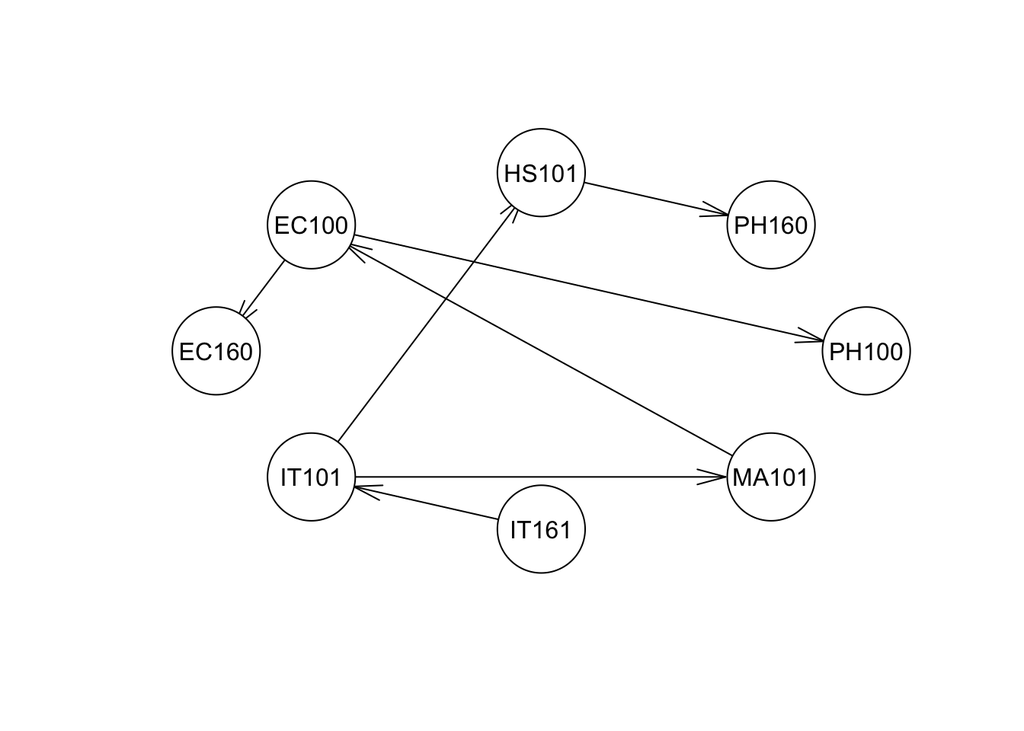

```r
course.grades<- lapply(course.grades,as.factor)
course.grades<- data.frame(course.grades)
course.grades.net<- hc(course.grades[,-9], score='k2')
plot(course.grades.net)
```

## Problem 2

Using the data, learn the CPTs for each course node.

```r
course.grades.fit <- bn.fit(course.grades.net,course.grades[,-9])
course.grades.fit
```

```
##
##   Bayesian network parameters
##
##   Parameters of node EC100 (multinomial distribution)
##
## Conditional probability table:
##
##      MA101
## EC100         AA         AB         BB         BC         CC         CD
##    AA 0.75000000 0.07692308 0.03846154 0.01851852 0.00000000 0.00000000
##    AB 0.00000000 0.46153846 0.25000000 0.05555556 0.00000000 0.00000000
##    BB 0.25000000 0.23076923 0.32692308 0.22222222 0.04081633 0.00000000
##    BC 0.00000000 0.15384615 0.28846154 0.27777778 0.32653061 0.00000000
##    CC 0.00000000 0.07692308 0.09615385 0.24074074 0.32653061 0.04166667
##    CD 0.00000000 0.00000000 0.00000000 0.12962963 0.26530612 0.33333333
##    DD 0.00000000 0.00000000 0.00000000 0.03703704 0.04081633 0.50000000
##    F  0.00000000 0.00000000 0.00000000 0.01851852 0.00000000 0.12500000
##      MA101
## EC100         DD          F
##    AA 0.00000000 0.00000000
##    AB 0.00000000 0.00000000
##    BB 0.00000000 0.00000000
##    BC 0.00000000 0.00000000
##    CC 0.00000000 0.00000000
##    CD 0.04761905 0.00000000
##    DD 0.19047619 0.00000000
##    F  0.76190476 1.00000000
##
##   Parameters of node EC160 (multinomial distribution)
##
## Conditional probability table:
##
##      EC100
## EC160         AA         AB         BB         BC         CC         CD
##    AA 0.42857143 0.22727273 0.05714286 0.04166667 0.00000000 0.00000000
##    AB 0.42857143 0.22727273 0.08571429 0.04166667 0.08333333 0.00000000
##    BB 0.14285714 0.31818182 0.20000000 0.22916667 0.08333333 0.03448276
##    BC 0.00000000 0.22727273 0.42857143 0.43750000 0.36111111 0.17241379
##    CC 0.00000000 0.00000000 0.22857143 0.25000000 0.30555556 0.34482759
##    CD 0.00000000 0.00000000 0.00000000 0.00000000 0.11111111 0.27586207
```

[output cut: 130 more lines]

```
##    BC 0.08333333 0.08000000 0.08823529 0.24489796 0.23809524 0.20000000
##    CC 0.00000000 0.00000000 0.11764706 0.12244898 0.14285714 0.11428571
##    CD 0.00000000 0.00000000 0.05882353 0.02040816 0.14285714 0.20000000
##    DD 0.00000000 0.00000000 0.02941176 0.02040816 0.00000000 0.22857143
##    F  0.00000000 0.00000000 0.00000000 0.00000000 0.00000000 0.00000000
##      IT101
## HS101         DD          F
##    AA 0.00000000 0.00000000
##    AB 0.00000000 0.00000000
##    BB 0.00000000 0.00000000
##    BC 0.04347826 0.00000000
##    CC 0.26086957 0.00000000
##    CD 0.13043478 0.08333333
##    DD 0.52173913 0.58333333
##    F  0.04347826 0.33333333
```

The first argument, “course.grades.net”, is a pre-specified network structure or graphical model that defines the relationships between variables in the dataset. The second argument, “course.grades[,-9]”, is the data used to estimate the parameters of the model, excluding the 9th column.

Let us visualise these a little bit.

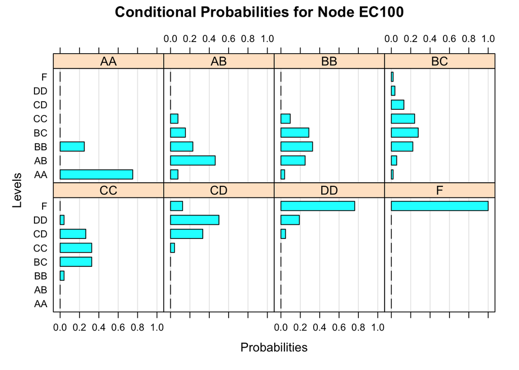

```r
bn.fit.barchart(course.grades.fit$EC100)
```

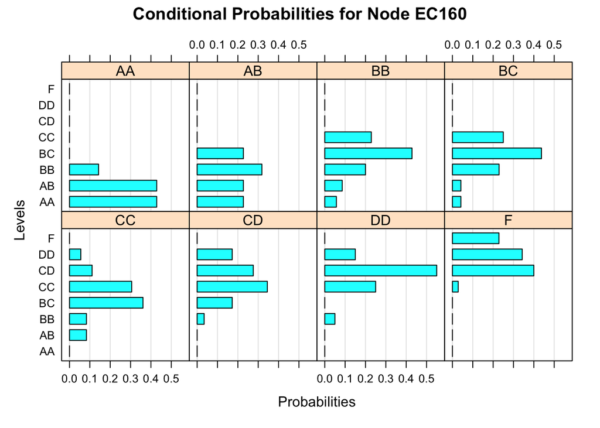

```r
bn.fit.barchart(course.grades.fit$EC160)
```

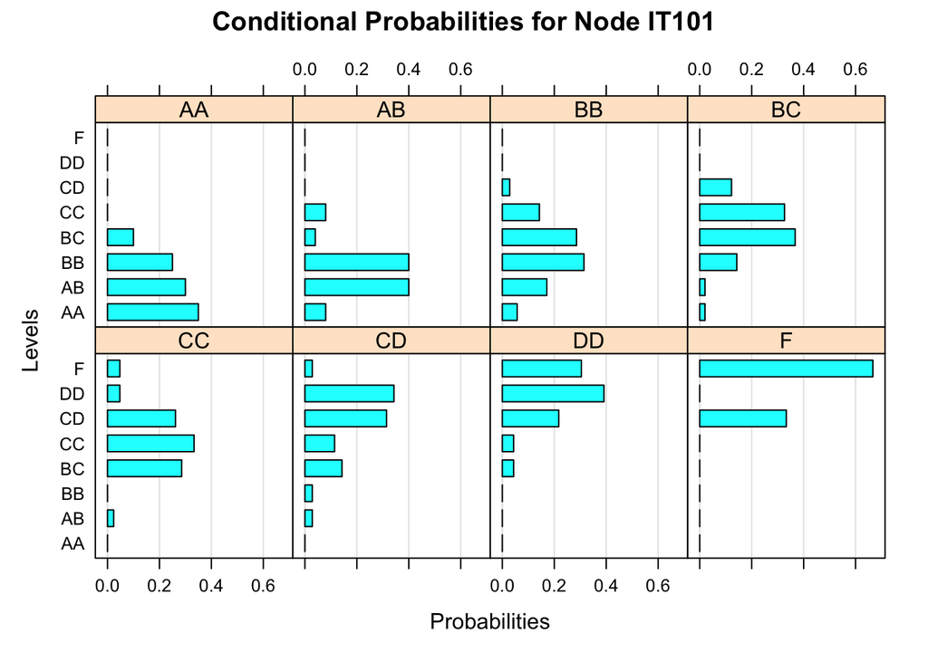

```r
bn.fit.barchart(course.grades.fit$IT101)
```

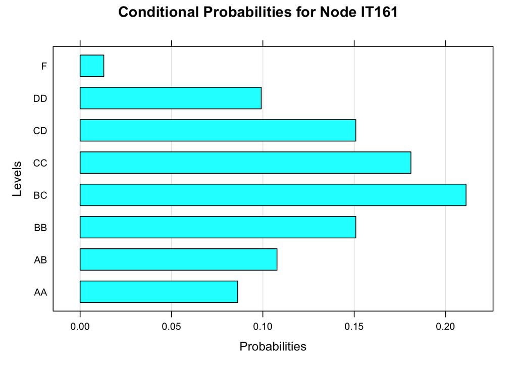

```r
bn.fit.barchart(course.grades.fit$IT161)
```

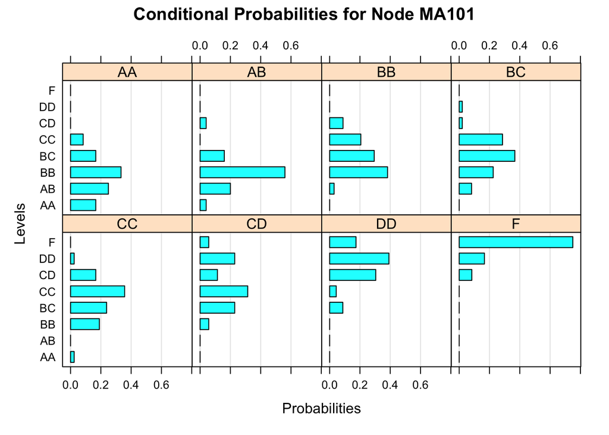

```r
bn.fit.barchart(course.grades.fit$MA101)
```

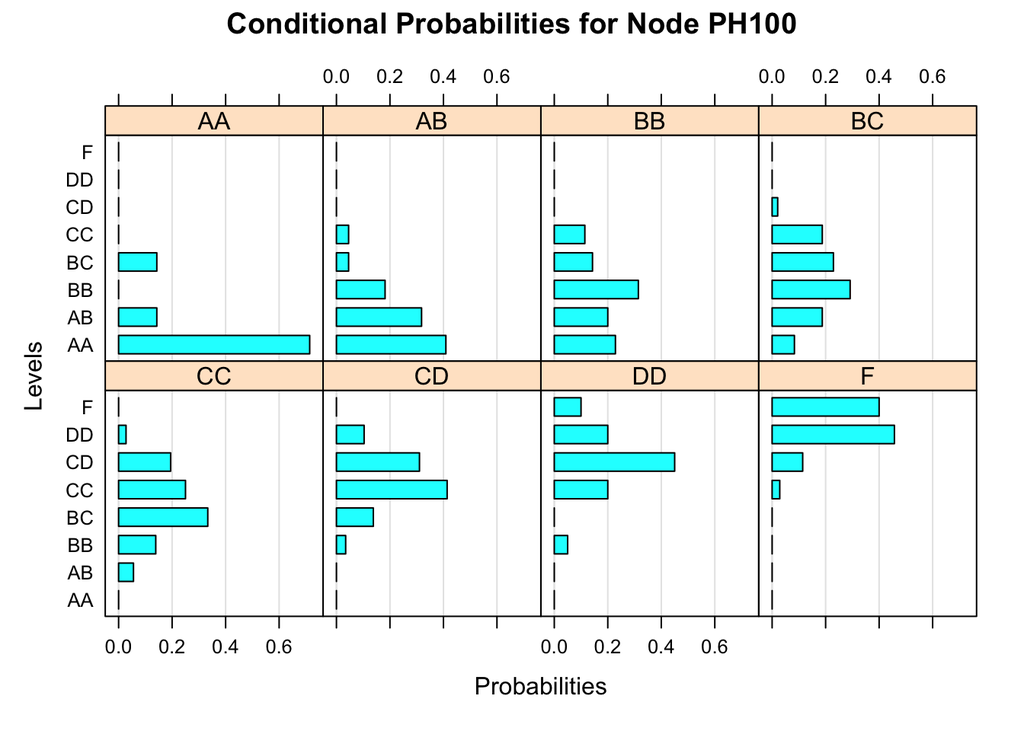

```r
bn.fit.barchart(course.grades.fit$PH100)
```

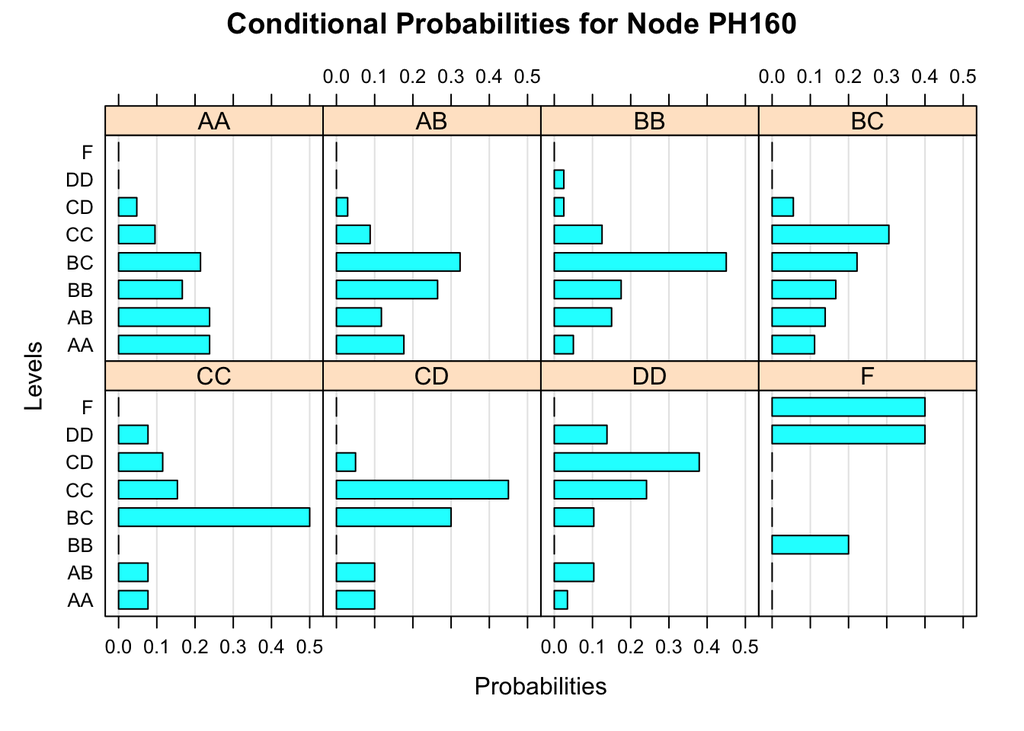

```r
bn.fit.barchart(course.grades.fit$PH160)
```

## Problem 3

What grade will a student get in PH100 if he earns DD in EC100, CC in IT101 and CD in MA101.

```r
course.grades.PH100 <- data.frame( cpdist(course.grades.fit, nodes = c("PH100"),evidence = ( (EC100=="DD") & (IT101=="CC") &( MA101== "CD"))))

df <- course.grades.PH100 %>%
  group_by(PH100) %>%
  summarise(counts = n())
```

Next we are using the dplyr library to group the data frame “course.grades.PH100” by the “PH100” variable and to summarize the counts of each value of “PH100”. The resulting data frame is stored in the object “df”.

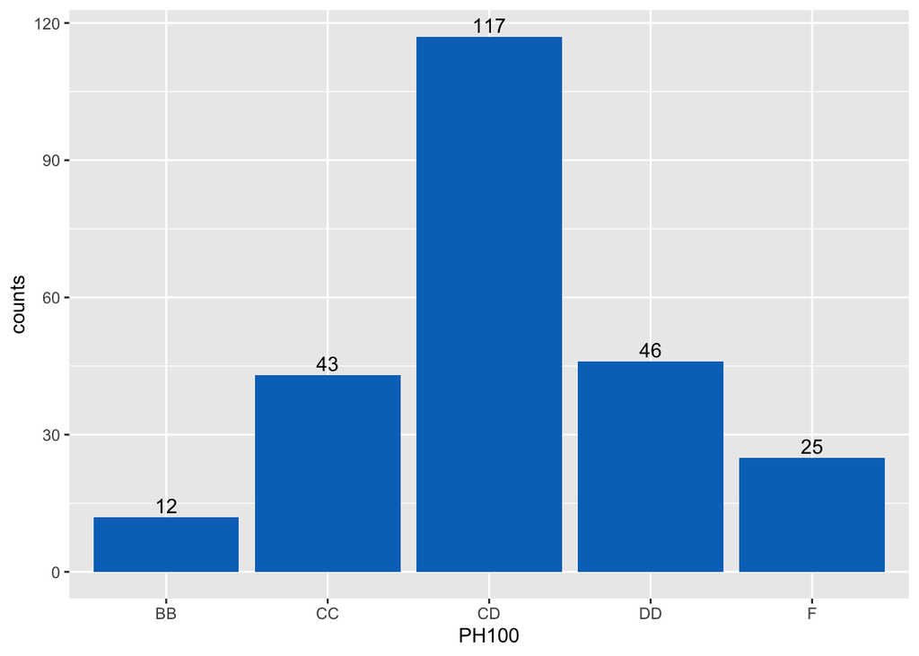

```r
ggplot(df, aes(x = PH100, y = counts)) +
  geom_bar(fill = "#0073C2FF", stat = "identity") +
  geom_text(aes(label = counts), vjust = -0.3)
```

Here we are using the ggplot2 library to create a bar plot of the summarized data. The ggplot function takes the “df” data frame as its data argument, and the “aes” function specifies that the x-axis should represent the “PH100” variable and the y-axis should represent the “counts”. The “geom_bar” function creates the bar plot with a blue fill color, and the “geom_text” function adds the count values as labels to the bars. The “vjust” argument adjusts the vertical position of the labels to avoid overlapping with the bars.

## Problem 4

The last column in the data file indicates whether a student qualifies for an internship program or not. From the given data, take 70 percent data for training, and build a naive Bayes classifier (considering that the grades earned in different courses are independent of each other) which takes in the student’s performance and returns the qualification status with a probability. Test your classifier on the remaining 30 percent data.

Let us split the data first.

```r
set.seed(101)
sample <-  sample.int(n = nrow(course.grades), size = floor(0.7*nrow(course.grades)), replace=F)
course.grades.train <-course.grades[sample,]
course.grades.test<- course.grades[-sample,]
```

Let us create a classifier based of Bayesian System.

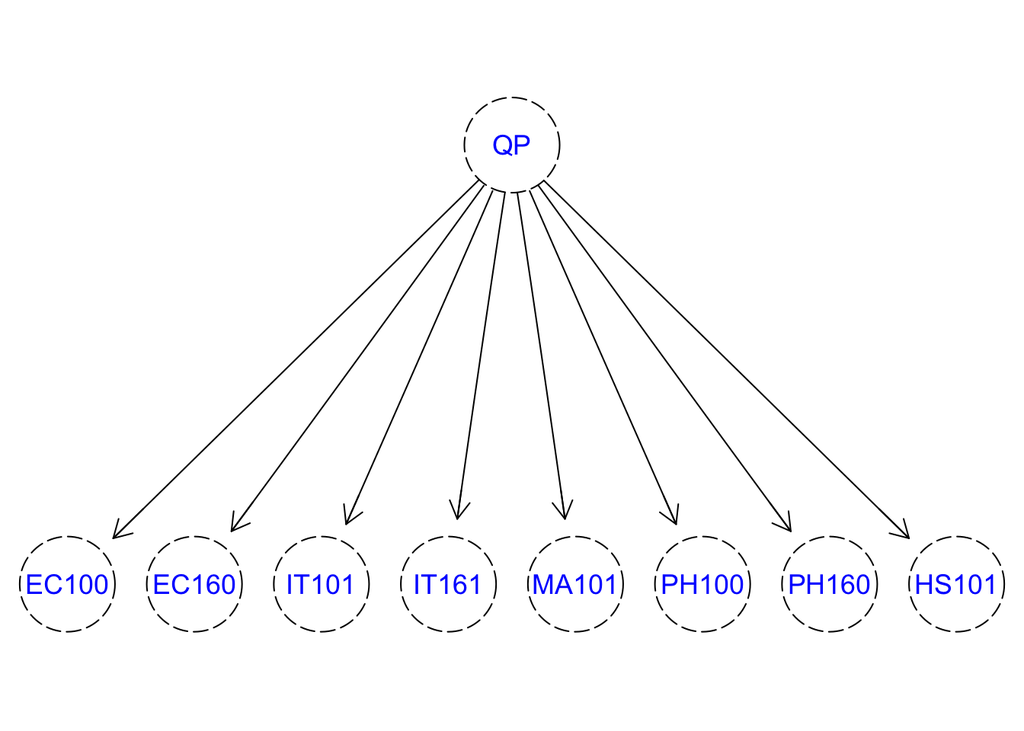

```r
nb.grades <- nb(class="QP", dataset=course.grades.train)
plot(nb.grades)
```

Training the classifier.

```r
nb.grades <- lp(nb.grades,course.grades.train, smooth=0)
nb.grades$.params
```

```
## $EC100
##      QP
## EC100           n           y
##    AA 0.000000000 0.037037037
##    AB 0.000000000 0.148148148
##    BB 0.000000000 0.222222222
##    BC 0.000000000 0.287037037
##    CC 0.055555556 0.185185185
##    CD 0.166666667 0.111111111
##    DD 0.314814815 0.009259259
##    F  0.462962963 0.000000000
##
## $EC160
##      QP
## EC160          n          y
##    AA 0.00000000 0.07407407
##    AB 0.00000000 0.09259259
##    BB 0.01851852 0.19444444
##    BC 0.01851852 0.36111111
##    CC 0.12962963 0.22222222
##    CD 0.46296296 0.03703704
##    DD 0.25925926 0.01851852
##    F  0.11111111 0.00000000
##
## $IT101
##      QP
## IT101          n          y
##    AA 0.00000000 0.06481481
##    AB 0.00000000 0.13888889
##    BB 0.05555556 0.23148148
##    BC 0.01851852 0.28703704
##    CC 0.11111111 0.20370370
##    CD 0.33333333 0.07407407
##    DD 0.35185185 0.00000000
##    F  0.12962963 0.00000000
##
## $IT161
##      QP
## IT161           n           y
##    AA 0.000000000 0.111111111
```

[output cut: 45 more lines]

```
##      QP
## HS101           n           y
##    AA 0.000000000 0.231481481
##    AB 0.000000000 0.212962963
##    BB 0.055555556 0.250000000
##    BC 0.148148148 0.157407407
##    CC 0.148148148 0.092592593
##    CD 0.203703704 0.046296296
##    DD 0.370370370 0.009259259
##    F  0.074074074 0.000000000
##
## $QP
## QP
##         n         y
## 0.3333333 0.6666667
```

Testing the classifier.

```r
p <- predict(nb.grades,course.grades.test)
cm <- table(predicted_on_test_data=p, actual_data=course.grades.test$QP)
cm
```

```
##                       actual_data
## predicted_on_test_data  n  y
##                      n 17  0
##                      y  1 52
```

Evaluating results.

```r
bnclassify:::accuracy(p, course.grades.test$QP)
```

```
## [1] 0.9857143
```